# Proyecto-Mineria_de_Datos-ajustado

## > Limpieza de datos

```python
df.isnull().sum()
```

```
producto               0
sede                   0
precio                 0
publicidad             0
descuento              0
popularidad          125
tiempo_en_estante    150
stock_inicial          0
promocion              0
demanda_regional       0
ventas                 0
dtype: int64
```

```python
df_sin_duplicados = df.drop_duplicates().copy()
df_sin_duplicados[df_sin_duplicados.duplicated()]
```

|  | producto | sede | precio | publicidad | descuento | popularidad | tiempo_en_estante | stock_inicial | promocion | demanda_regional | ventas |
| --- | --- | --- | --- | --- | --- | --- | --- | --- | --- | --- | --- |

```python
# Se imputan los datos usando bootstraping en la variable Popularidad ya que no posee una distribución normal.
#Extraer los valores no nulos
popularidad_no_nulos = df_sin_duplicados['popularidad'].dropna().values

#Determinar la cantidad de valores nulos
popularidad_nulos = df_sin_duplicados['popularidad'].isna().sum()

#Generar una muestra con reemplazo de los valores de Popularidad existentes, del mismo tamaño que los nulos
muestra_bootstrap_popularidad = np.random.choice(popularidad_no_nulos, size=popularidad_nulos, replace=True)

#Asignar valores a los nulos en la columna Popularidad
df_sin_duplicados.loc[df_sin_duplicados['popularidad'].isna(), 'popularidad'] = muestra_bootstrap_popularidad
```

```python
# Se imputan los datos con la Media de la variable tiempo_en_estante.
TE_median = df_sin_duplicados['tiempo_en_estante'].median()
df_sin_duplicados.loc[:, 'tiempo_en_estante'] = df_sin_duplicados['tiempo_en_estante'].fillna(TE_median)
```

```python
df_sin_duplicados['producto'].isna().sum()
df_sin_duplicados['sede'].isna().sum()
df_sin_duplicados['precio'].isna().sum()
df_sin_duplicados['publicidad'].isna().sum()
df_sin_duplicados['descuento'].isna().sum()
df_sin_duplicados['popularidad'].isna().sum()
df_sin_duplicados['tiempo_en_estante'].isna().sum()
df_sin_duplicados['stock_inicial'].isna().sum()
df_sin_duplicados['promocion'].isna().sum()
df_sin_duplicados['demanda_regional'].isna().sum()
df_sin_duplicados['ventas'].isna().sum()
print(f'producto: {df_sin_duplicados["producto"].isna().sum()} valores faltantes')
print(f'sede: {df_sin_duplicados["sede"].isna().sum()} valores faltantes')
print(f'precio: {df_sin_duplicados["precio"].isna().sum()} valores faltantes')
print(f'publicidad: {df_sin_duplicados["publicidad"].isna().sum()} valores faltantes')
print(f'descuento: {df_sin_duplicados["descuento"].isna().sum()} valores faltantes')
print(f'popularidad: {df_sin_duplicados["popularidad"].isna().sum()} valores faltantes')
print(f'tiempo_en_estante: {df_sin_duplicados["tiempo_en_estante"].isna().sum()} valores faltantes')
print(f'stock_inicial: {df_sin_duplicados["stock_inicial"].isna().sum()} valores faltantes')
print(f'promocion: {df_sin_duplicados["promocion"].isna().sum()} valores faltantes')
print(f'demanda_regional: {df_sin_duplicados["demanda_regional"].isna().sum()} valores faltantes')
print(f'ventas: {df_sin_duplicados["ventas"].isna().sum()} valores faltantes')
```

```
producto: 0 valores faltantes
sede: 0 valores faltantes
precio: 0 valores faltantes
publicidad: 0 valores faltantes
descuento: 0 valores faltantes
popularidad: 0 valores faltantes
tiempo_en_estante: 0 valores faltantes
stock_inicial: 0 valores faltantes
promocion: 0 valores faltantes
demanda_regional: 0 valores faltantes
ventas: 0 valores faltantes
```

```python
df_sin_duplicados.isnull().sum()
```

```
producto             0
sede                 0
precio               0
publicidad           0
descuento            0
popularidad          0
tiempo_en_estante    0
stock_inicial        0
promocion            0
demanda_regional     0
ventas               0
dtype: int64
```

### >> Ajustar outliers

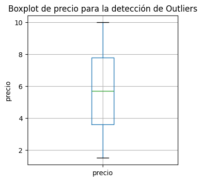

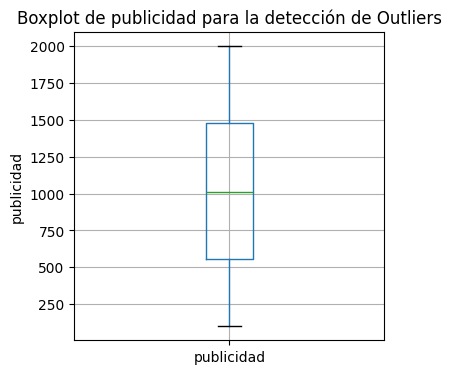

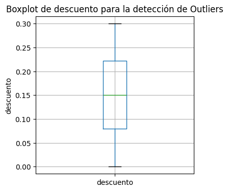

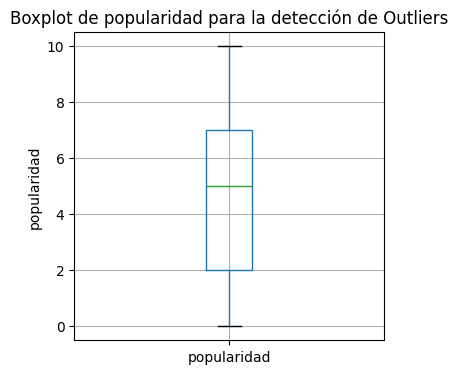

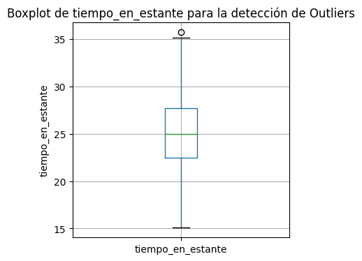

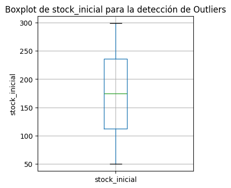

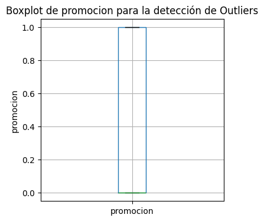

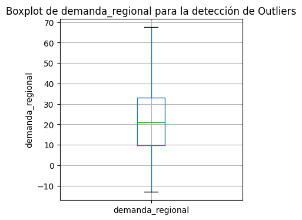

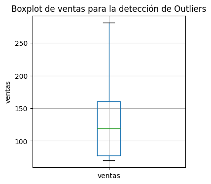

```python
outliers_var = df_sin_duplicados.drop(['producto', 'sede'], axis=1)
for i in outliers_var:
    plt.figure(figsize=(4, 4))
    df_sin_duplicados.boxplot(column=i)
    plt.title(f'Boxplot de {i} para la detección de Outliers')
    plt.ylabel(i)
    plt.show()
```

## > Transformación de datos

```python
df_sin_duplicados['popularidad'] = df_sin_duplicados['popularidad'].astype(int)
df_sin_duplicados['popularidad'].dtypes
```

```
dtype('int64')
```

### >> Codificar variables categóricas

```python
df_sd_con_dummies = df_sin_duplicados.copy()
```

```python
df_sd_con_dummies = pd.get_dummies(df_sd_con_dummies, columns=['producto', 'sede'], drop_first=True, dtype=int)
df_sd_con_dummies
```

|  | precio | publicidad | descuento | popularidad | tiempo_en_estante | stock_inicial | promocion | demanda_regional | ventas | producto_Arroz | ... | producto_Galletas | producto_Huevos | producto_Jugo | producto_Leche | producto_Pan | producto_Queso | sede_Cartago | sede_Heredia | sede_Puntarenas | sede_San José |
| --- | --- | --- | --- | --- | --- | --- | --- | --- | --- | --- | --- | --- | --- | --- | --- | --- | --- | --- | --- | --- | --- |
| 0 | 2.21 | 1247.21 | 0.08 | 4 | 29.8 | 64 | 0 | 23.130754 | 98.60 | 0 | ... | 0 | 0 | 0 | 0 | 0 | 1 | 0 | 0 | 1 | 0 |
| 1 | 3.29 | 667.96 | 0.06 | 6 | 25.8 | 132 | 1 | 17.722831 | 165.81 | 0 | ... | 0 | 0 | 0 | 0 | 0 | 0 | 0 | 0 | 1 | 0 |
| 2 | 7.90 | 880.55 | 0.10 | 8 | 23.5 | 97 | 1 | 26.530718 | 182.41 | 0 | ... | 0 | 0 | 0 | 0 | 0 | 0 | 0 | 1 | 0 | 0 |
| 3 | 1.94 | 513.63 | 0.14 | 1 | 29.7 | 176 | 0 | 15.756335 | 70.00 | 0 | ... | 0 | 0 | 1 | 0 | 0 | 0 | 0 | 0 | 0 | 1 |
| 4 | 5.69 | 1935.44 | 0.09 | 4 | 24.4 | 95 | 0 | 21.570997 | 117.18 | 0 | ... | 0 | 0 | 0 | 0 | 0 | 1 | 0 | 0 | 1 | 0 |
| ... | ... | ... | ... | ... | ... | ... | ... | ... | ... | ... | ... | ... | ... | ... | ... | ... | ... | ... | ... | ... | ... |
| 2495 | 5.68 | 1423.36 | 0.12 | 6 | 26.6 | 95 | 0 | 20.954214 | 138.90 | 0 | ... | 1 | 0 | 0 | 0 | 0 | 0 | 0 | 1 | 0 | 0 |
| 2496 | 9.58 | 814.48 | 0.10 | 6 | 25.8 | 205 | 0 | 21.573779 | 128.00 | 1 | ... | 0 | 0 | 0 | 0 | 0 | 0 | 0 | 1 | 0 | 0 |
| 2497 | 4.76 | 1890.96 | 0.12 | 7 | 22.2 | 194 | 0 | 23.993637 | 156.33 | 0 | ... | 1 | 0 | 0 | 0 | 0 | 0 | 0 | 0 | 1 | 0 |
| 2498 | 5.11 | 1654.17 | 0.23 | 9 | 21.4 | 281 | 0 | 28.507158 | 170.52 | 1 | ... | 0 | 0 | 0 | 0 | 0 | 0 | 0 | 1 | 0 | 0 |
| 2499 | 7.57 | 1216.62 | 0.14 | 4 | 28.0 | 225 | 0 | 22.725345 | 108.73 | 0 | ... | 0 | 0 | 1 | 0 | 0 | 0 | 0 | 0 | 1 | 0 |

2500 rows × 22 columns

## Interpretación de la Exploración de los Datos

En el Análisis Exploratorio de Datos para el conjuto de datos 'ventas_supermercado.xlsx' encontramos que:

- El conjunto de datos contiene 2500 datos y 11 columnas, con datos numéricos y cadenas de texto.
- No se encontraron datos Duplicados.
- Se encontró que dos de las Varianbles ('popularidad', 'tiempo_en_estante') tenian datos perdidos, NaN o Null.
- No se determinaron valores extremos significativos.
- Se indentificaron las variables 'tiempo_en_estante' y 'demada_regional' con una distribución normal.
- Se utilizó la técnica de bootstraping, para imputar los datos faltantes en la variable: 'popularidad', ya que ésta no cuenta con una distribucion normal.
- Usando la mediana, se imputaron los datos faltantes de la variable 'tiempo_en_estante'.
- La variable 'popularidad' contiene datos enteros, pero se muestra como datos reales, por lo que sé transformó en integer.
- Se codificaron las variables categóricas: 'sede' y 'producto', usando dummies. El tamaño del conjunto de datos cambió a 2500 x 22.

## > Análisis de Correlación

```python
correlation_matrix = df_sd_con_dummies.corr()
correlation_matrix
```

|  | precio | publicidad | descuento | popularidad | tiempo_en_estante | stock_inicial | promocion | demanda_regional | ventas | producto_Arroz | ... | producto_Galletas | producto_Huevos | producto_Jugo | producto_Leche | producto_Pan | producto_Queso | sede_Cartago | sede_Heredia | sede_Puntarenas | sede_San José |
| --- | --- | --- | --- | --- | --- | --- | --- | --- | --- | --- | --- | --- | --- | --- | --- | --- | --- | --- | --- | --- | --- |
| precio | 1.000000 | -0.016007 | -0.027033 | 0.014787 | 0.002072 | -0.000655 | -0.008565 | 0.017567 | 0.077560 | 0.018334 | ... | 0.016526 | -0.027333 | -0.020533 | -0.000633 | -0.011957 | 0.008675 | -0.006801 | 0.002646 | 0.007589 | -0.015497 |
| publicidad | -0.016007 | 1.000000 | -0.006274 | 0.010638 | -0.001749 | -0.008013 | 0.023942 | -0.002979 | 0.196785 | 0.001812 | ... | 0.025361 | -0.008605 | 0.012520 | -0.000843 | 0.007028 | -0.001106 | 0.036584 | -0.017192 | -0.025697 | 0.013279 |
| descuento | -0.027033 | -0.006274 | 1.000000 | -0.027768 | 0.024629 | 0.000058 | 0.014947 | -0.026569 | -0.045522 | 0.035038 | ... | -0.025639 | -0.006406 | 0.001614 | -0.026968 | 0.016141 | 0.007979 | -0.027581 | -0.004616 | 0.005710 | 0.020218 |
| popularidad | 0.014787 | 0.010638 | -0.027768 | 1.000000 | -0.763040 | -0.013974 | 0.007364 | 0.843702 | 0.811957 | -0.002232 | ... | -0.010109 | -0.014868 | 0.013782 | 0.019794 | 0.016934 | -0.001061 | 0.000295 | -0.004197 | 0.002088 | -0.004309 |
| tiempo_en_estante | 0.002072 | -0.001749 | 0.024629 | -0.763040 | 1.000000 | 0.021452 | -0.003515 | -0.726883 | -0.690498 | -0.027522 | ... | 0.020729 | 0.017479 | -0.017072 | -0.006064 | 0.003346 | 0.010272 | 0.003707 | -0.008164 | -0.001666 | 0.002271 |
| stock_inicial | -0.000655 | -0.008013 | 0.000058 | -0.013974 | 0.021452 | 1.000000 | 0.005525 | -0.008405 | -0.011448 | 0.037346 | ... | -0.004236 | 0.027004 | -0.043096 | 0.004556 | -0.020460 | 0.014424 | -0.019016 | 0.040864 | 0.008113 | -0.026194 |
| promocion | -0.008565 | 0.023942 | 0.014947 | 0.007364 | -0.003515 | 0.005525 | 1.000000 | 0.002437 | 0.353257 | -0.006936 | ... | 0.015861 | -0.010240 | 0.003305 | -0.029076 | 0.015490 | -0.015259 | 0.002722 | -0.001750 | 0.019477 | -0.008263 |
| demanda_regional | 0.017567 | -0.002979 | -0.026569 | 0.843702 | -0.726883 | -0.008405 | 0.002437 | 1.000000 | 0.769784 | 0.008071 | ... | -0.016276 | -0.016307 | 0.019077 | 0.013963 | 0.018722 | -0.000612 | -0.012473 | -0.000387 | 0.022186 | -0.001593 |
| ventas | 0.077560 | 0.196785 | -0.045522 | 0.811957 | -0.690498 | -0.011448 | 0.353257 | 0.769784 | 1.000000 | 0.012375 | ... | -0.005832 | -0.017246 | 0.024198 | -0.000592 | 0.014536 | 0.002822 | 0.018593 | 0.001626 | -0.001646 | -0.019685 |
| producto_Arroz | 0.018334 | 0.001812 | 0.035038 | -0.002232 | -0.027522 | 0.037346 | -0.006936 | 0.008071 | 0.012375 | 1.000000 | ... | -0.113336 | -0.110827 | -0.116058 | -0.117283 | -0.111835 | -0.110574 | 0.033484 | 0.021721 | -0.022377 | -0.017749 |
| producto_Café | 0.003424 | -0.024019 | 0.015942 | -0.019987 | 0.005311 | -0.031663 | 0.043715 | -0.022819 | -0.017694 | -0.112086 | ... | -0.111353 | -0.108888 | -0.114027 | -0.115231 | -0.109878 | -0.108639 | -0.006908 | 0.010694 | -0.030623 | 0.020590 |
| producto_Cereal | -0.009993 | 0.007454 | 0.005814 | -0.024311 | 0.023007 | 0.008541 | 0.004210 | -0.027557 | -0.026382 | -0.110068 | ... | -0.109348 | -0.106927 | -0.111974 | -0.113156 | -0.107899 | -0.106683 | 0.022024 | -0.024377 | -0.008705 | -0.020699 |
| producto_Galletas | 0.016526 | 0.025361 | -0.025639 | -0.010109 | 0.020729 | -0.004236 | 0.015861 | -0.016276 | -0.005832 | -0.113336 | ... | 1.000000 | -0.110102 | -0.115299 | -0.116516 | -0.111103 | -0.109851 | 0.006172 | -0.022521 | 0.015821 | -0.005963 |
| producto_Huevos | -0.027333 | -0.008605 | -0.006406 | -0.014868 | 0.017479 | 0.027004 | -0.010240 | -0.016307 | -0.017246 | -0.110827 | ... | -0.110102 | 1.000000 | -0.112747 | -0.113937 | -0.108644 | -0.107419 | -0.033581 | 0.004064 | 0.032992 | 0.014166 |
| producto_Jugo | -0.020533 | 0.012520 | 0.001614 | 0.013782 | -0.017072 | -0.043096 | 0.003305 | 0.019077 | 0.024198 | -0.116058 | ... | -0.115299 | -0.112747 | 1.000000 | -0.119314 | -0.113772 | -0.112489 | -0.001236 | 0.025956 | 0.005074 | 0.006234 |
| producto_Leche | -0.000633 | -0.000843 | -0.026968 | 0.019794 | -0.006064 | 0.004556 | -0.029076 | 0.013963 | -0.000592 | -0.117283 | ... | -0.116516 | -0.113937 | -0.119314 | 1.000000 | -0.114973 | -0.113677 | -0.020472 | 0.012840 | 0.011419 | -0.009888 |
| producto_Pan | -0.011957 | 0.007028 | 0.016141 | 0.016934 | 0.003346 | -0.020460 | 0.015490 | 0.018722 | 0.014536 | -0.111835 | ... | -0.111103 | -0.108644 | -0.113772 | -0.114973 | 1.000000 | -0.108396 | -0.009553 | -0.012039 | 0.003360 | 0.014664 |
| producto_Queso | 0.008675 | -0.001106 | 0.007979 | -0.001061 | 0.010272 | 0.014424 | -0.015259 | -0.000612 | 0.002822 | -0.110574 | ... | -0.109851 | -0.107419 | -0.112489 | -0.113677 | -0.108396 | 1.000000 | 0.023910 | -0.012135 | -0.003302 | 0.018230 |
| sede_Cartago | -0.006801 | 0.036584 | -0.027581 | 0.000295 | 0.003707 | -0.019016 | 0.002722 | -0.012473 | 0.018593 | 0.033484 | ... | 0.006172 | -0.033581 | -0.001236 | -0.020472 | -0.009553 | 0.023910 | 1.000000 | -0.255316 | -0.256588 | -0.258494 |
| sede_Heredia | 0.002646 | -0.017192 | -0.004616 | -0.004197 | -0.008164 | 0.040864 | -0.001750 | -0.000387 | 0.001626 | 0.021721 | ... | -0.022521 | 0.004064 | 0.025956 | 0.012840 | -0.012039 | -0.012135 | -0.255316 | 1.000000 | -0.252503 | -0.254379 |
| sede_Puntarenas | 0.007589 | -0.025697 | 0.005710 | 0.002088 | -0.001666 | 0.008113 | 0.019477 | 0.022186 | -0.001646 | -0.022377 | ... | 0.015821 | 0.032992 | 0.005074 | 0.011419 | 0.003360 | -0.003302 | -0.256588 | -0.252503 | 1.000000 | -0.255646 |
| sede_San José | -0.015497 | 0.013279 | 0.020218 | -0.004309 | 0.002271 | -0.026194 | -0.008263 | -0.001593 | -0.019685 | -0.017749 | ... | -0.005963 | 0.014166 | 0.006234 | -0.009888 | 0.014664 | 0.018230 | -0.258494 | -0.254379 | -0.255646 | 1.000000 |

22 rows × 22 columns

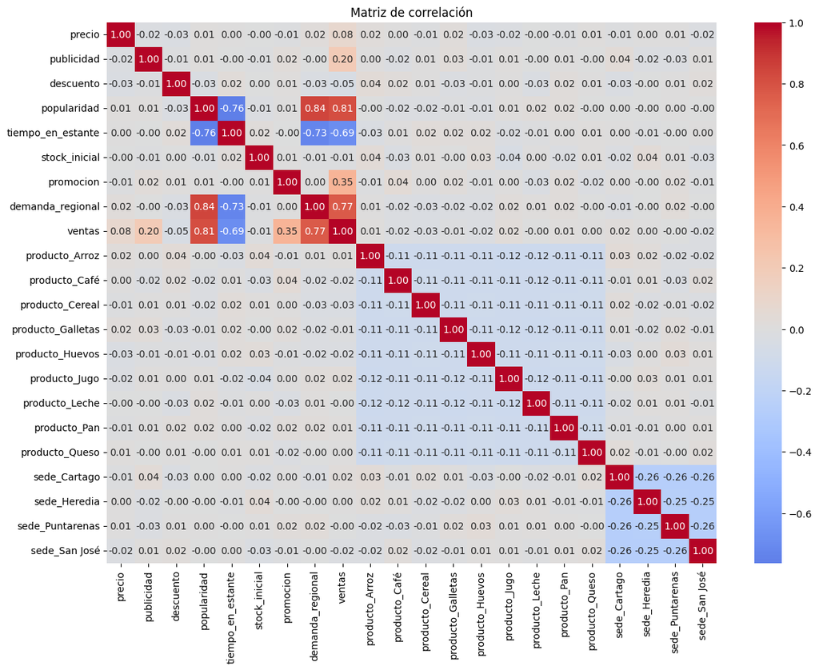

```python
plt.figure(figsize=(14, 10))
sns.heatmap(correlation_matrix, annot=True, fmt=".2f", cmap='coolwarm', center=0)
plt.title("Matriz de correlación")
plt.show()
```

```python
# Umbral de correlación
umbral = 0.6

# Obtener pares de variables con correlación por encima del umbral
correlaciones_altas = (
    correlation_matrix.where(np.triu(np.ones(correlation_matrix.shape), k=1).astype(bool))
    .stack()
    .reset_index()
)

# Renombrar columnas
correlaciones_altas.columns = ['Variable_1', 'Variable_2', 'Correlacion']

# Filtrar por valor absoluto del umbral
correlaciones_filtradas = correlaciones_altas[np.abs(correlaciones_altas['Correlacion']) > umbral]

# Mostrar resultado
print(correlaciones_filtradas.sort_values(by='Correlacion', ascending=False))
```

```
            Variable_1         Variable_2  Correlacion
63         popularidad   demanda_regional     0.843702
64         popularidad             ventas     0.811957
126   demanda_regional             ventas     0.769784
81   tiempo_en_estante             ventas    -0.690498
80   tiempo_en_estante   demanda_regional    -0.726883
60         popularidad  tiempo_en_estante    -0.763040
```